# Capitulo 2

### Boxplots y puntos esparcidos

Estos se usan cuando los datos tienen una variable categórica y una o más variables continuas, nos interesan los valores de la variable continua en diferentes niveles de la variable categórica.

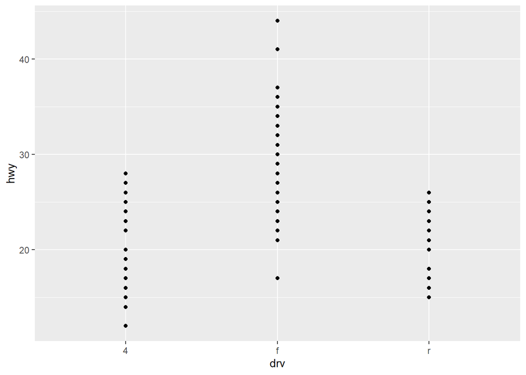

```r
ggplot(mpg, aes(drv, hwy)) +
  geom_point()
```

Ya que hay muchos puntos sobrepuestos, podemos usar `geom_jitter()`, `geom_boxplot()` o `geom_violin()`.

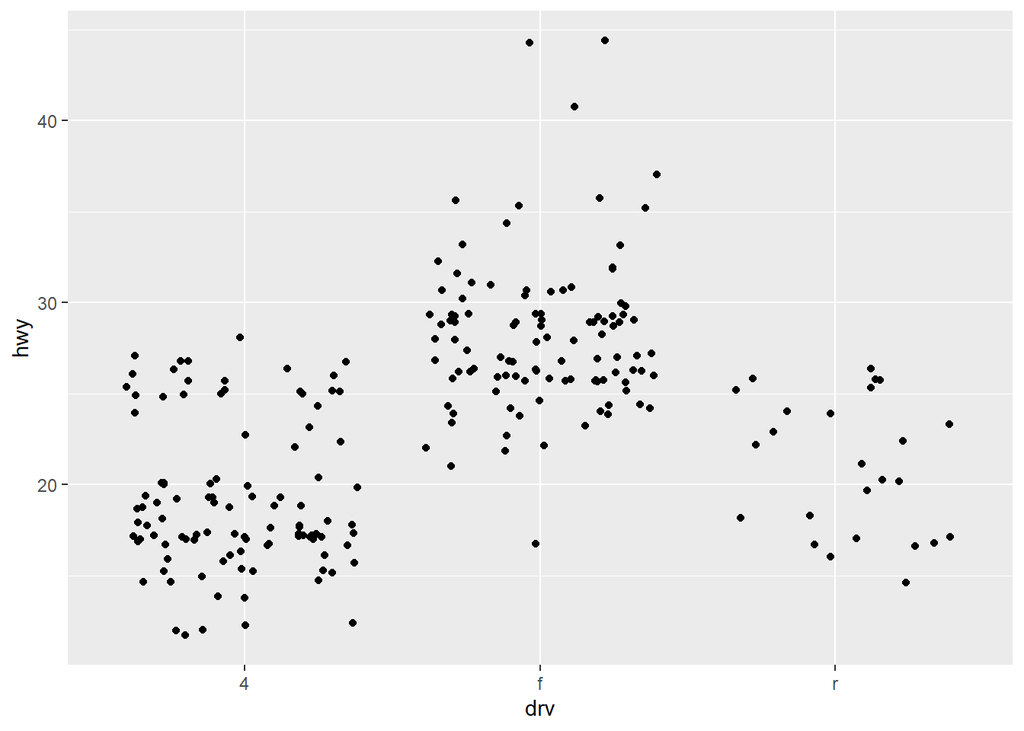

```r
ggplot(mpg, aes(drv, hwy)) + geom_jitter()
```

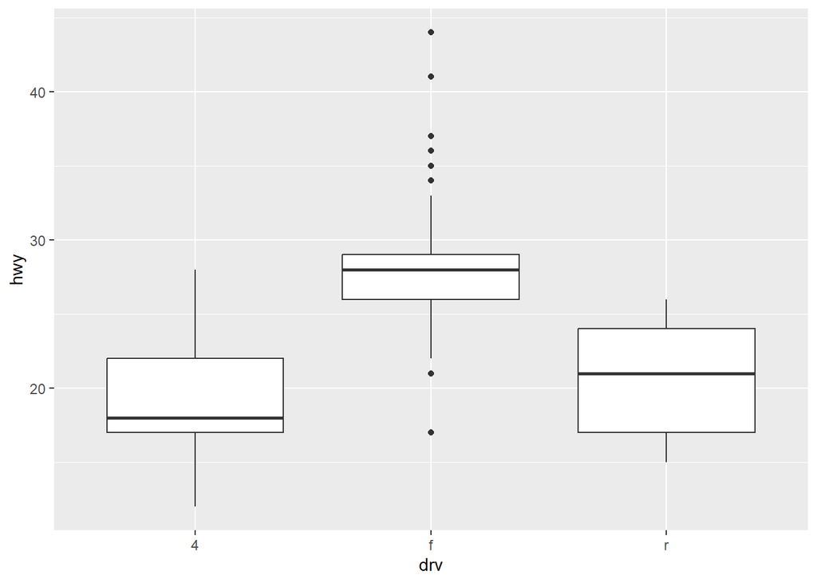

```r
ggplot(mpg, aes(drv, hwy)) + geom_boxplot()
```

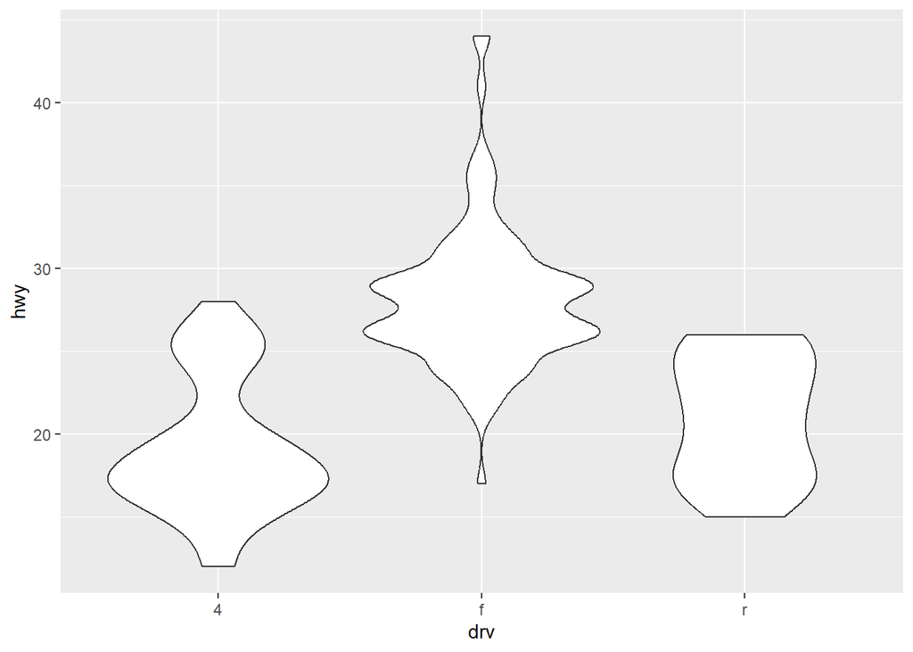

```r
ggplot(mpg, aes(drv, hwy)) + geom_violin()
```

Cada uno tiene sus ventajas y desventajas, también podemos controlar `size`, `colour`, `shape` y para el boxplot y violin podemos controlar el color externo `colour` o el color interno con `fill`